# Laboratório 4: Estruturas de Controle de Fluxo e Condicionais no R

Métodos Computacionais 1

2026-08-24

# Introdução

As funções de controle de fluxo no R servem para **direcionar o caminho que o seu código deve seguir**. Elas determinam se um bloco de código deve ser executado, pulado ou repetido com base em condições lógicas.

### Uso de if, else if, ifelse

#### Uso de if**:

Uma instrução if executa um bloco de código apenas quando uma condição é TRUE. A condição vai entre parênteses, o código entre chaves, e um else opcional fornece o que acontece caso contrário.

No codigo abaixo se a nota do aluno é maior do que 60 ele, e escrito no console “aprovado”.

```r
nota <- 72

if (nota >= 60) {
  print("aprovado")
}
```

```
## [1] "aprovado"
```

A seguir incluimos else para que seja escrito no console “reprovado” quando o critério nota >=60 não for atendido.

```r
nota <- 55

if (nota >= 60) {
  print("aprovado")
} else {
  print("reprovado")
}
```

```
## [1] "reprovado"
```

O *else* deve ser colocado na mesma linha da } que fecha o if.

#### Uso de else if

o uso de **else if** é recomendado quando 2 ou mais condições são avaliadas e cada um delas resulta numa ação diferente. O R avalia as condições em sequência e executa a tarefa que segue a primeira condição satisfeita, as condições seguintes não são avaliadas.

Como exemplo, considere o codigo abaixo que atribui conceitos aos alunos de acordo com a nota.

```r
nota <- 85

if (nota >= 90) {
  conceito <- "A"
} else if (nota >= 80) {
  conceito <- "B"
} else if (nota >= 70) {
  conceito <- "C"
} else {
  conceito <- "F"
}

print(conceito)
```

```
## [1] "B"
```

A ordem das condições importa: como $85 \geq 80$ foi verificado antes de $85 \geq 70$, o conceito atribuído foi B. Se as verificações $85 \geq 70$ fosse colocada antes de 85 $\geq 80$, o conceito atribuído seria “C”.

**if** e **else if** só devem ser usados com objetos nucleares, não são aplicáveis a vetores.

#### Avaliando uma ou mais condições

**Exemplo:** atribuindo classifiacções de aprovação segundo nota e frequência do aluno

```r
nota <- 75
frequencia <- "suficiente"

if (nota >= 60 && frequencia == "suficiente") {
  print("aprovado")
} else if (nota >= 60 && frequencia == "insuficiente") {
  print("reprovado por infrequencia")
} else if (nota < 60 && frequencia == "suficiente") {
  print("reprovado por nota")
} else {
  print("reprovado por nota e frequência")
}
```

```
## [1] "aprovado"
```

Os operadores lógicos **&** e **&&** são usados quando desejamos avaliar se 2 condições são simultaneamente satisfeitas e **|** e **||** quando desejamos avaliar se pelo menos uma de 2 condições é satisfeita. Enquanto **&** e **|** pode ser aplicados a vetores, o operadores **&&** e **||** são aplicáveis somente a objetos elementares.

Os símbolo **&&** e **||** são chamados de lógicos curto circuito. Isso porque quando usamos **&&**, se a primeira condição é falsa, ele não analisa a segunda. Por outro lado, quando usamos **||**, a segunda condição não é avaliada quando a primeira é verdadeira.

Quando usamos **&** e **||** aplicado a vetores, as condições são avaliadas para cada um dos elementos dos vetores.

#### Uso de ifelse:

Enquanto *if* avalia objetos elementares, **ifelse** é aplicado a vetores. Ele a avalia a condição para cada elemento do vetor e retorna outro vetor de mesmo comprimento com os resultados.

```r
notas<-c(56,80,60)
frequencia=c("insuficiente","suficiente","insuficiente")
resultado=ifelse(notas>=60 & frequencia=="suficiente","aprovado", "reprovado")
resultado
```

```
## [1] "reprovado" "aprovado"  "reprovado"
```

#### Uso de ifelse em sequência

- **ifelse** pode ser usado em sequência.

Primeira condição é atendida?

Sim: realiza tarefa 1

Não: avalia uma segunda condição

Segunda condição é atendida?

Sim: realiza tarefa 2

Não: avalia uma terceira condição

e assim por diante.

```r
notas<-c(56,80,60)
frequencia=c("suficiente","suficiente","insuficiente")
resultado=ifelse(notas>=60 & frequencia=="suficiente","aprovado", ifelse(nota>=60 & frequencia=="insuficiente","reprovado por frequencia",ifelse(nota<60 & frequencia=="suficiente","reprovado por nota","reprovado por nota e frequência")))
```

- Muito cuidado deve ser tomado ao fechar parênteses quando usamos **ifelse** em sequência. Uma alternativa mais interessante é usar a função **when** do pacote **dplyr**, que será assunto de aula futura.

**Exemplo**: Construindo uma função que receba informação sobre as variaveis medidas para clientes de uma instituição financeira: renda (numérica), dívida ativa (sim ou não) e escore de credito (numérica) e avalie a concessão de crédito.

**Função para classificar o risco de crédito de clientes**

```r
avaliar_credito <- function(score, renda, divida_ativa) {

# Análise da presença de dívida ativa"

    if (divida_ativa == "Sim") {
    return("Crédito Negado - Dívida Ativa")
    }

# Análise combinada de Score e Renda

    if (score >= 750) {
    return("Crédito Aprovado - Linha Premium")
    } else if (score >= 500 & renda >= 3000) {
    return("Crédito Aprovado - Linha Standard")
    } else if (score >= 500 & renda < 3000) {
    return("Crédito Aprovado com fiador")
    } else {
    return("Crédito Negado")
  }
}

# Testando a função com um cliente específico
avaliar_credito(score = 620, renda = 2500, divida_ativa = FALSE)
```

```
## [1] "Crédito Aprovado com fiador"
```

**Observação:**

- quando dentro de uma função colocamos mais de um return, a funçao é interrompida após o primeiro return() ser bem sucedido.
- na função acima, se a condição do primeiro **if** é atendida, as condições seguintes não são avaliadas.

**Atividades:**

1. Usando “ifelse”, crie uma função similar a função acima, mas que possa ser aplicada a vetores.
2. Execute essa função com os vetores: score = c(620,3000,1000), renda = c(2500,1000,6000) e divida_ativa = c(“nao”, “sim”,“sim”))

## Estruturas de Repetição (Loops)

Os loops servem para repetir um bloco de código várias vezes.

### Uso de for

- **O que faz**: Repete um bloco de código um **número fixo e predeterminado de vezes**, usando uma sequência como guia.
- **Quando usar**: Quando você sabe exatamente quantas vezes precisa repetir a operação antes do loop começar.
- **Por que usar**: Para iterar sobre índices, arquivos em uma pasta ou posições específicas de uma lista.
- **Exemplo**: Construa uma função que receba um conjunto de dados de tamanho n, $n\geq3$, observado ao longo dos dias, e calcule as médias móveis para intervalos de 3 dias. A primeira media móvel é dada pela média das observações de ordem 1, 2 e 3, a segunda pela média das observações de ordem 2, 3 e 4, e assim por diante até o último valor dado pela média das observações de ordem n-2, n-1 e n. Desse modo, o vetor de médias móveis terá tamanho n - 2. A função também deverá retornar o gráfico de linhas para o conjunto de dados, acrescidos da linha correspondente às médias móveis.

```r
media_movel=function(x){  # cria a funçao
n<- length(x)             # calcula o comprimento de x
mm=numeric(n-2)           # cria um vetor de zeros de tamanho n-2 para armazenar as médias moveis
for(i in 3:n){
mm[i-2]=mean(x[(i-2):i])       #calcula media movel e atualiza mm
}
# construção do grafico
grafico=plot(1:n,x,xlab="dias",ylab="medição",type="b",pch=1,cex.lab=1,ylim=c(-2,3))
lines(2:(n-1),mm,col=2,type="b",lty=2,pch=16)
legend("topright",col=c(1,2),pch=c(1,16),legend=c("medição","Media Movel"),cex=0.7,horiz=TRUE,bty="n")
# resutados fornecidos pela função
return(list(mediasm=mm,grafico=grafico))
}
```

### Atividades:

1. Execute a função com os valores dos retornos da IBOVESPA para 50 dias úteis consecutivos:

retornos_ibov <- c(0.12, -1.45, 0.88, -0.23,1.15, -0.92, -1.84, 2.05, 0.34, -0.76, 1.42,-1.18,0.05, 0.91, -2.11, 0.67, 1.23, -0.45, -0.89, 0.54,1.98, -1.32, -0.11, 0.76, -0.98, 0.43,-1.67,2.21,-0.54, 0.12, -0.87, 1.09, -1.24, 0.34, 0.95, -2.43,1.76, -0.08, -0.65, 1.12, -1.54, 0.89, 0.23,-0.43,1.34, -1.98, 0.56, 0.11, -0.78, 1.21)

2. Modifique a função definindo o intervalo de cálculo da media móvel pelo argumento de nome **tamanho** e execute a função para tamanho igual a 7.
3. Usando for, acrescente à função uma variàvel que retorne a diferença entre o valor observado em um dia e a média móvel precedente a ele. O comprimento da variável diferença é **n - tamanho**.

#### Uso de While

- **O que faz**: Repete um bloco de código **enquanto uma condição for verdadeira**. Ele checa a condição *antes* de cada repetição.
- **Quando usar**: Quando você **não sabe** quantas vezes o código precisará rodar, mas sabe a condição que deve fazê-lo parar.
- **Por que usar**: Útil para simulações, algoritmos de otimização ou jogos onde o fim depende de um evento incerto.

**Exemplo: Substituindo for por while na função media_movel**

```r
media_movelW=function(x){      # cria a funçao
n<- length(x)                  # calcula o comprimento de x
mm=numeric(n-2)                # cria um vetor de zeros de tamanho n-2                                 # para armazenar as médias moveis
i=3 #inicia o contador
while (i<=n) {
  mm[i-2]=mean(x[(i-2):i])    #calcula media movel e atualiza mm
  i=i+1                       #atualiza o contador
}
# construção do grafico
grafico=plot(1:n,x,xlab="dias",ylab="medição",type="b",pch=1,cex.lab=1,ylim=c(-2,3))
lines(2:(n-1),mm,col=2,type="b",lty=2,pch=16)
legend("topright",col=c(1,2),pch=c(1,16),legend=c("medição","Media Movel"),cex=0.7,horiz=TRUE,bty="n")
# define resultados da função
return(list(mediasm=mm,grafico=grafico))
}
```

**Exemplo: Minimização por Gradiente Descendente**

Queremos encontrar o ponto mínimo da função de custo $f(x) = x^2$. Sabemos analiticamente que o mínimo está em $x = 0$. Para encontrar esse ponto numericamente, usaremos o algoritmo do Gradiente Descendente. A regra de atualização do algoritmo é:

$$(x_{novo}=x_{atual}-\alpha \cdot
f^{\prime }(x_{atual})$$
Onde:$f'(x) = 2x$ (a derivada/gradiente da função).$\alpha$ (alfa) é a taxa de aprendizado (tamanho do passo).

Escreva um script em R utilizando a estrutura while que parta de um ponto inicial (ex: $x_0 = 10$) e continue atualizando o valor de $x$ até que o algoritmo convirja. O critério de convergência será quando a diferença absoluta entre o $x_{novo}$ e o $x_{atual}$ for menor do que uma tolerância de ($\epsilon = 0.0001$). Ao final, o programa deve exibir: O valor final de $x$ que minimiza a função e O número total de iterações necessárias até a convergência para essa solução.

```r
# Parâmetros iniciais do problema
x_atual <- 10           # Ponto de partida inicial
taxa_aprendizado <- 0.1 # Alpha (tamanho do passo)
tolerancia <- 0.0001    # Critério de convergência (Epsilon)
max_iter <- 1000        # Limite de segurança contra loops infinitos

# Variáveis de controle do laço
diferenca <- Inf     # Inicializa a diferença como "infinita"
iteracao <- 0        # Contador de passos

# 3. Laço while para avaliar a convergência
while (diferenca > tolerancia && iteracao < max_iter) {
# Calcula o gradiente no ponto atual (Derivada de x^2 é 2x)
  gradiente <- 2 * x_atual
# Aplica a regra de atualização
  x_novo <- x_atual - taxa_aprendizado * gradiente

# Calcula a distância percorrida neste passo (Critério de Convergência)
  diferenca <- abs(x_novo - x_atual)

# Atualiza as variáveis para a próxima iteração
  x_atual <- x_novo
  iteracao <- iteracao + 1
}

# 4. Exibição dos resultados
cat("--- Resultado da Otimização ---\n",
"Ponto mínimo encontrado (x):", round(x_atual, 5), "\n",
"Número de iterações para convergir:", iteracao, "\n")
```

```
## --- Resultado da Otimização ---
##  Ponto mínimo encontrado (x): 0.00035
##  Número de iterações para convergir: 46
```

**Observaçao:** a função **cat** é similar à função **paste**, vista anteriormente. $\text{\n}$ é usado para quebrar a linha. Use a função de ajuda para saber mais sobre ela.

**Atividades:**

1. Incorpore o código acima numa função como os seguintes argumentos: x_atual,taxa_aprendizado, alpha, tolerancia; e que retorne o valor final de x e o número de iterações realizadas.
2. Execute a função mudando o valor inicial de x_atual para 5.
3. Modifique o codigo acima de modo que ele retorne o ponto de minino da função $x^2-10x+100$.

#### Uso de repeat e break

A função **repeat** repete um laço incondicionalmente e a função **break** interrompe o laço imediatamente.

**Exemplo: Uma função deve receber um número e elevá-lo ao quadrado, o valor obtido deve ser novamente elevado ao quadrado e assim por diante até que o resultado obtido seja maior do que 1000, quando o loop deve ser interrompido.

```r
x2<-function(x){
repeat{
  x=x^2
  if(x>1000){break}
}
print(x)
}
```

**Executando a função para x = 2**

```r
x2(2)
```

```
## [1] 65536
```

- **break** pode ser usado dentro de **for** e **while** combinado com uma condição **if** para avaliar um condição no corpo do laço.

**Atividade**

1 - Escolha um número qualquer (ex: `numero <- 7`) e construa um loop `for` que exiba a tabuada desse número do 1 ao 10 no console, no formato: *“7 x 1 = 7”*, *“7 x 2 = 14”*, etc. (Dica: use a função `paste()` ou `cat()`).

2 - Imagine que você está jogando um dado de 6 lados repetidamente. Crie um loop `while` que simule lançamentos seguidos desse dado. O loop deve continuar rodando e imprimindo o valor sorteado, mas deve ser **interrompido imediatamente com um `break`** assim que o número sorteado for `6`. Use sample(1:6,1) para sortear o numero. Nesse caso não é preciso indicar uma condição de parada ao criar o while(), podemos criar um loop infinito com uma condição de parada resultando em **break**. Para criar um loop infinito com **while**, fazemos **While(TRUE)**.

3 - Implemente a tarefa acima usando **for** com no maximo 100 iterações.

#### Uso da função next

Essa função é usada para interromper um ciclo do loop e pular para o proximo ciclo.

**Exemplo:** Sortear um numero entre 0 e 100 retórna-lo se ele for par. Repetir esse procedimento até que 20 numeros pares sejam obtidos. Os números devem ser armazenados num vetor e devem ser printados no console.

```r
# Criar um vetor vazio para armazenar os números pares
numeros_pares <- NULL  #NULL indica ausência de valor
while (length(numeros_pares) < 20) {
# Sorteia um número entre 0 e 100

  numero_sorteado <- sample(0:100, 1)

# SE O NÚMERO FOR ÍMPAR:

  if (numero_sorteado %% 2 != 0) {
  next

# next pula o restante do código e vai direto para a próxima repetição
  }

# Este trecho só é executado se o número for  PAR (se for ímpar, o next barrou antes)

numeros_pares <- c(numeros_pares, numero_sorteado) #acrescenta o novo numero para sorteado ao vetor
}

# Imprime o vetor final com os 20 números pares no console
print(numeros_pares)
```

```
##  [1]  4 72 10 14 30 86 16 32 96 88 12  0  0 32 92 20 54 66  8 10
```

**Atividade:**

1. refaça a atividade acima usando **for**, considerando que o processo será repetido até obter 20 números pares ou até completar 100 repetições, o que acontecer primeiro.

```r
# Vamos criar um vetor numérico para receber os valores aceitos (pré-alocação de memória)

x <- numeric(500)
i=1
while (i<=500){
# Simulando o sorteio de um número (ex: média 100, desvio 20)

  valor_sorteado <- rnorm(1, mean = 100, sd = 20)

# Uso do NEXT: Se o número for maior que 110, inicia o proximo ciclo
  if (valor_sorteado > 110) {
    next
  }

# Grava o número aceito no vetor pré-alocado
  x[i] <- valor_sorteado
  i=i+1      #atualiza o contador
}
print(x)
```

```
##   [1]  83.73914  80.14974 102.33821  89.12128  77.16240 101.50248  68.43743
##   [8] 102.60004  91.55702 109.82922  99.70269  78.33625  83.72061  83.57995
##  [15] 109.77435 103.57852  99.75154  84.93206  85.88229  84.65128  89.24982
##  [22]  75.43200 100.06404  86.38044  67.99274 107.87902 101.00624  70.40346
##  [29]  63.91781 102.59516  55.83999 105.81615  75.41349  61.01149  74.62190
##  [36]  71.58348 108.11402  71.31542  81.62124  83.94125 109.50898  81.95894
##  [43]  80.57916  75.80997  79.22492 103.40502 104.60996  94.00621  82.87877
##  [50] 100.15844 100.39904  97.94493  82.07640  82.63826  65.11935 102.69277
##  [57]  70.70852  87.99541  92.26521  84.83559  86.90640  77.72015  97.61671
##  [64]  88.19369  89.91575 107.34262  67.98751  95.14903  91.58884 109.11740
##  [71] 109.32693  90.94786  86.28155 104.96707  98.10494  90.03170 108.37940
##  [78]  97.31069  75.53720 105.59291  95.13476 106.41315  83.81488 109.00691
##  [85] 107.77309 102.98560 104.09312 105.13691  80.63679 103.84025 106.86763
##  [92]  79.47755  87.47219 108.92492  78.41165  80.93069  97.35106  93.25004
##  [99]  78.17189 104.45433  92.76291  85.13396  98.21554 101.53219 104.37812
```

[output cut: 57 more lines]

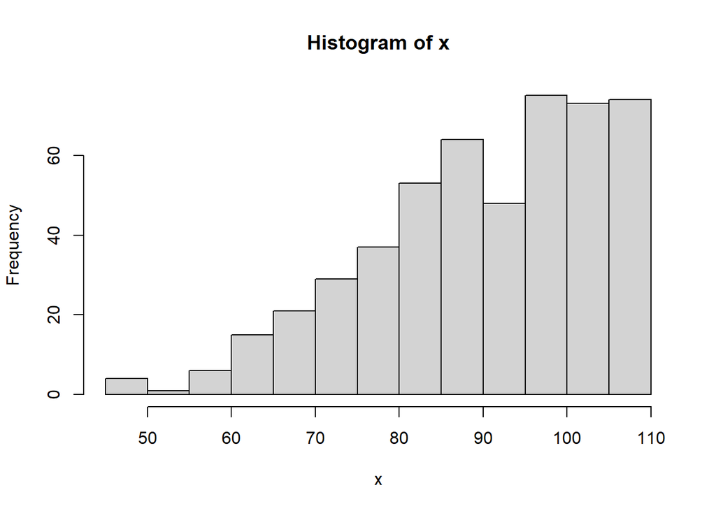

```r
hist(x)
```

**Atividade**

1. Crie uma função que simule o lançamento simultâneo de 2 dados e que retorne a razão entre a soma e a diferença dos valores obtidos somente quando o resultado for definido (denominador diferente de zero).